# Visualizing Data: Waffle Charts, Word Clouds, and Regression Analysis

# Word Clouds

Word clouds are one of my favorite ways to visualize text or categorical data. The bigger and bolder a word appears, the more frequently it shows up in the data. In this section, I'll use word clouds to explore both literary text and my own immigration dataset.

*By Mohammad Sayem Chowdhury*

Luckily, Python has a great package for generating word clouds, called `wordcloud` by Andreas Mueller. I use it here to quickly turn text or categorical data into a visual summary. Let's see it in action!

If you haven't installed the `wordcloud` package yet, you can do so easily. I always like to keep my environment ready for creative visualizations.

```python
# install wordcloud
# !pip3 install wordcloud==1.8.1

# import package and its set of stopwords
from wordcloud import WordCloud, STOPWORDS,ImageColorGenerator

print ('Wordcloud is installed and imported!')
```

```
Wordcloud is installed and imported!
```

Word clouds are perfect for high-level analysis of text data. To show how flexible they are, I'll take a quick detour from immigration data and analyze a classic novel: *Alice's Adventures in Wonderland* by Lewis Carroll. Let's download the text and see what stands out!

```python
import urllib

# open the file and read it into a variable alice_novel
alice_novel = urllib.request.urlopen('https://cf-courses-data.s3.us.cloud-object-storage.appdomain.cloud/IBMDeveloperSkillsNetwork-DV0101EN-SkillsNetwork/Data%20Files/alice_novel.txt').read().decode("utf-8")
```

To make the word cloud more meaningful, I use a set of stopwords to filter out common words that don't add much insight. This helps the most interesting words stand out.

```python
stopwords = set(STOPWORDS)
```

```python
# Author: Mohammad Sayem Chowdhury
# Generate a word cloud from Alice in Wonderland (as a fun example)
alice_wc = WordCloud(
    background_color='white',
    max_words=2000,
    stopwords=stopwords
)
alice_wc.generate(alice_novel)
```

```
<wordcloud.wordcloud.WordCloud at 0x1a792111190>
```

Let's take a look at the word cloud I just generated. It's always fun to see which words pop out visually!

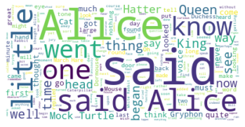

```python
plt.imshow(alice_wc, interpolation='bilinear')
plt.axis('off')
plt.show()
```

Some words, like "said," aren't very informative. I add them to the stopwords list and regenerate the word cloud for a cleaner, more insightful visualization.

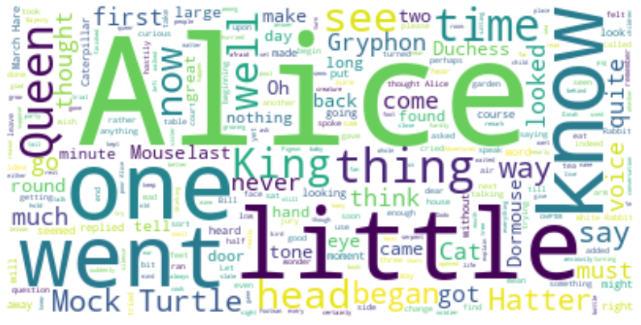

```python
stopwords.add('said')
alice_wc.generate(alice_novel)
fig = plt.figure(figsize=(14, 18))
plt.imshow(alice_wc, interpolation='bilinear')
plt.axis('off')
plt.show()
```

For extra creativity, I use a custom mask to shape the word cloud. Here, I use an Alice-themed mask to make the visualization even more fun and relevant to the story.

```python
alice_mask = np.array(Image.open('alice_mask.png'))
```

[figure not shown]

```python
fig = plt.figure(figsize=(14, 18))
plt.imshow(alice_mask, cmap=plt.cm.gray, interpolation='bilinear')
plt.axis('off')
plt.show()
```

[figure not shown]

```python
alice_wc = WordCloud(background_color='white', max_words=2000, mask=alice_mask, stopwords=stopwords)
alice_wc.generate(alice_novel)
fig = plt.figure(figsize=(14, 18))
plt.imshow(alice_wc, interpolation='bilinear')
plt.axis('off')
plt.show()
```

```python
# Author: Mohammad Sayem Chowdhury
max_words = 90
word_string = ''
for country in immigration_data.index.values:
    if country.count(" ") == 0:
        repeat_num_times = int(immigration_data.loc[country, 'Total'] / immigration_data['Total'].sum() * max_words)
        word_string += (country + ' ') * repeat_num_times
```

```python
wordcloud = WordCloud(background_color='white').generate(word_string)
print('Word cloud created!')
```

```
Word cloud created!
```

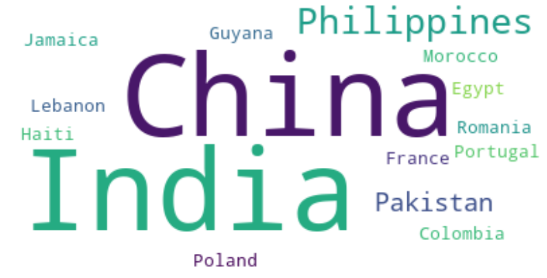

```python
plt.figure(figsize=(14, 18))
plt.imshow(wordcloud, interpolation='bilinear')
plt.axis('off')
plt.show()
```

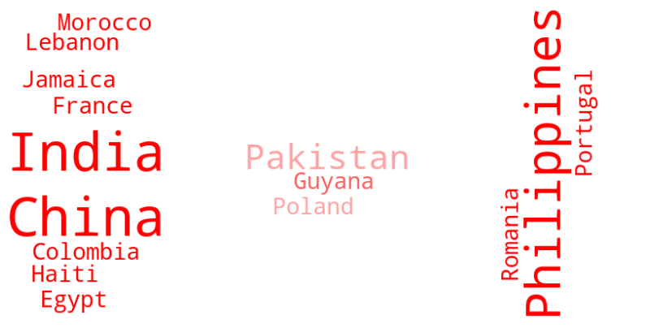

```python
canada_mask = np.array(Image.open('Flag-Canada.webp'))
wordcloud_canada = WordCloud(stopwords=stopwords, background_color="white", max_words=90, mask=canada_mask).generate(word_string)
image_colors = ImageColorGenerator(canada_mask)
plt.figure(figsize=(14, 18))
plt.imshow(wordcloud_canada.recolor(color_func=image_colors), interpolation="bilinear")
plt.axis("off")
plt.show()
```

# Regression Plots

Regression plots are a powerful way to explore trends and relationships in data. Here, I use seaborn to quickly create regression plots and uncover patterns in Canadian immigration over time.

*By Mohammad Sayem Chowdhury*

```python
# Author: Mohammad Sayem Chowdhury
# If seaborn is not installed, uncomment the next line:
# !pip install seaborn
import seaborn as sns
print('Seaborn ready!')
```

[output not shown]

To see the overall trend, I create a DataFrame with the total number of immigrants to Canada for each year. This sets the stage for a clear regression analysis.

```python
total_per_year = pd.DataFrame(immigration_data[years].sum(axis=0))
total_per_year.index = map(float, total_per_year.index)
total_per_year.reset_index(inplace=True)
total_per_year.columns = ['year', 'total']
total_per_year.head()
```

|  | year | total |
| --- | --- | --- |
| 0 | 1980.0 | 99137 |
| 1 | 1981.0 | 110563 |
| 2 | 1982.0 | 104271 |
| 3 | 1983.0 | 75550 |
| 4 | 1984.0 | 73417 |

With seaborn, it's easy to generate a regression plot that shows the trend in total immigration over time. I love how visually clear and informative these plots are.

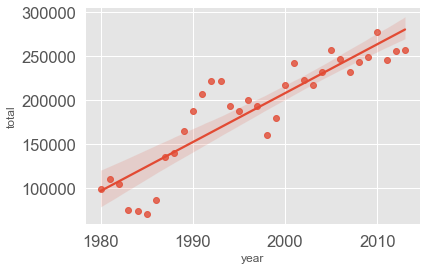

```python
sns.regplot(x='year', y='total', data=total_per_year)
plt.show()
```

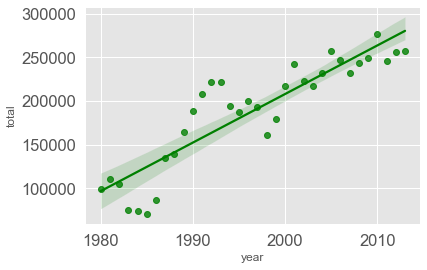

```python
sns.regplot(x='year', y='total', data=total_per_year, color='green')
plt.show()
```

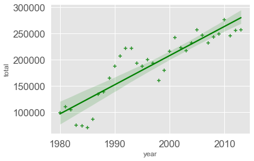

```python
ax = sns.regplot(x='year', y='total', data=total_per_year, color='green', marker='+')
plt.show()
```

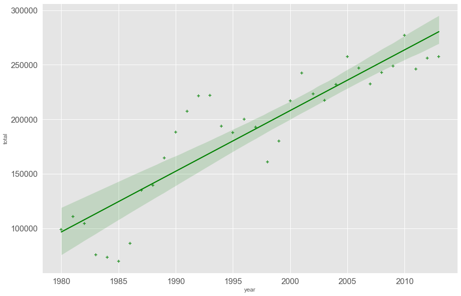

```python
plt.figure(figsize=(15, 10))
sns.regplot(x='year', y='total', data=total_per_year, color='green', marker='+')
plt.show()
```

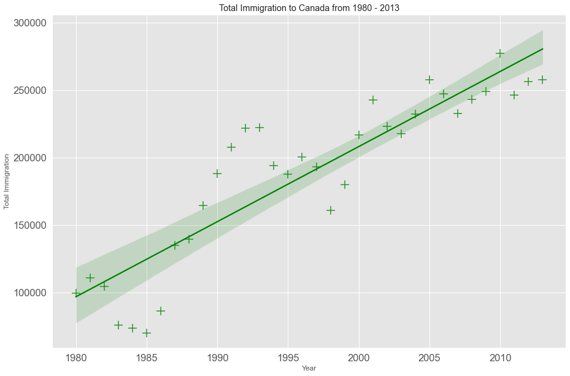

```python
plt.figure(figsize=(15, 10))
ax = sns.regplot(x='year', y='total', data=total_per_year, color='green', marker='+', scatter_kws={'s': 200})
ax.set(xlabel='Year', ylabel='Total Immigration')
ax.set_title('Total Immigration to Canada from 1980 - 2013')
plt.show()
```

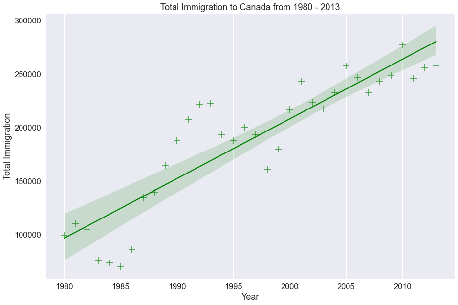

```python
plt.figure(figsize=(15, 10))
sns.set(font_scale=1.5)
ax = sns.regplot(x='year', y='total', data=total_per_year, color='green', marker='+', scatter_kws={'s': 200})
ax.set(xlabel='Year', ylabel='Total Immigration')
ax.set_title('Total Immigration to Canada from 1980 - 2013')
plt.show()
```

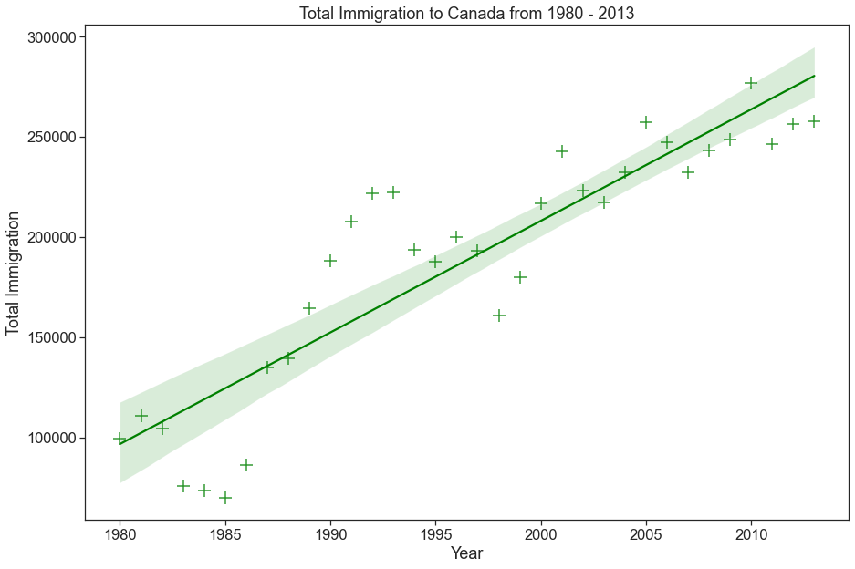

```python
plt.figure(figsize=(15, 10))
sns.set(font_scale=1.5)
sns.set_style('ticks')
ax = sns.regplot(x='year', y='total', data=total_per_year, color='green', marker='+', scatter_kws={'s': 200})
ax.set(xlabel='Year', ylabel='Total Immigration')
ax.set_title('Total Immigration to Canada from 1980 - 2013')
plt.show()
```

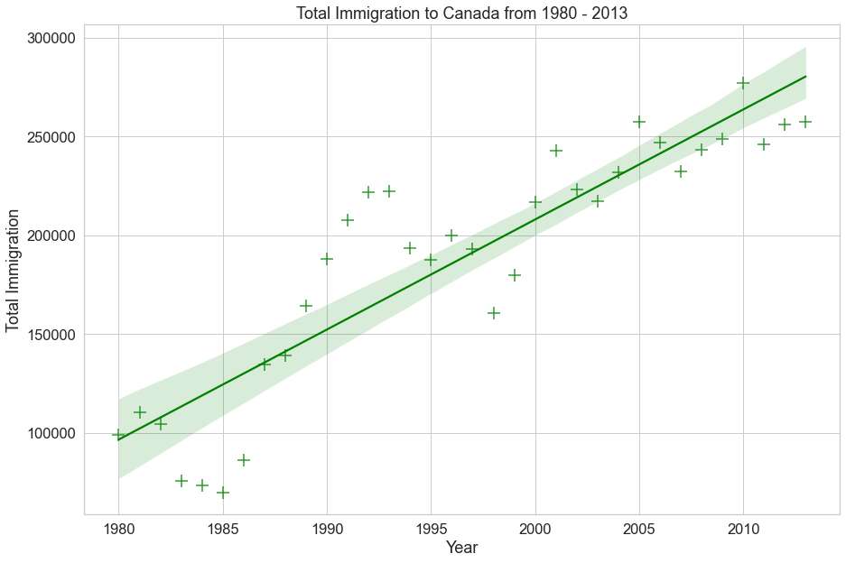

```python
plt.figure(figsize=(15, 10))
sns.set(font_scale=1.5)
sns.set_style('whitegrid')
ax = sns.regplot(x='year', y='total', data=total_per_year, color='green', marker='+', scatter_kws={'s': 200})
ax.set(xlabel='Year', ylabel='Total Immigration')
ax.set_title('Total Immigration to Canada from 1980 - 2013')
plt.show()
```

## My Own Exploration: Immigration from Denmark, Sweden, and Norway

I'm especially interested in the trends for Denmark, Sweden, and Norway. By summing their yearly totals and plotting a regression line, I can see how immigration from these countries has changed over time.

[figure not shown]

```python
# Author: Mohammad Sayem Chowdhury
nordic_yearly = immigration_data.loc[['Denmark', 'Norway', 'Sweden'], years].transpose()
nordic_total = pd.DataFrame(nordic_yearly.sum(axis=1))
nordic_total.reset_index(inplace=True)
nordic_total.columns = ['year', 'total']
nordic_total['year'] = nordic_total['year'].astype(int)
plt.figure(figsize=(15, 10))
sns.set(font_scale=1.5)
sns.set_style('whitegrid')
ax = sns.regplot(x='year', y='total', data=nordic_total, color='green', marker='+', scatter_kws={'s': 200})
ax.set(xlabel='Year', ylabel='Total Immigration')
ax.set_title('Immigration from Denmark, Sweden, and Norway to Canada (1980-2013)')
plt.show()
```

# Personal Reflections & Summary

Exploring data through waffle charts, word clouds, and regression plots has given me new insights into Canadian immigration trends and the power of visualization. Each technique brings out a different aspect of the story, and I hope my personal approach has made these concepts more relatable and inspiring.

If you have feedback or want to connect, feel free to reach out!

**Notebook by Mohammad Sayem Chowdhury**